# Figures for Paper

Anna-Leigh Brown

06/10/2020

# Summary statistics

First let’s look at only including tissues with detectable stmn2 or UNC13A CE

```r
clean_data_table = fread(file.path(here(),"data","nygc_junction_information.csv"))
clean_data_table = clean_data_table %>%
    mutate(call = fct_relevel(call,
                              "C/C", "C/G", "G/G")) %>%
    mutate(number_g_alleles = as.numeric(call) - 1) %>%
    mutate(unc13a_cryptic_leaf_psi = ifelse(is.na(unc13a_cryptic_leaf_psi),0,unc13a_cryptic_leaf_psi)) %>%
    mutate(stmn2_psi_groups = as.numeric(cut_interval(log10(stmn_2_cryptic_psi_leaf), n = 2))) %>%
    mutate(stmn2_psi_groups = case_when(stmn2_psi_groups == 1 ~ " Low STMN2",
                                      stmn2_psi_groups == 2 ~ "High STMN2",
                                      TRUE ~ "No STMN2"))

print(glue::glue("Number of unique patients: {clean_data_table[,length(unique(participant_id))]}"))
```

```
## Number of unique patients: 377
```

```r
print(glue::glue("Number of unique tissue samples: {clean_data_table[,length(unique(sample))]}"))
```

```
## Number of unique tissue samples: 1349
```

```r
print("Patients Per Disease Category")
```

```
## [1] "Patients Per Disease Category"
```

```r
clean_data_table[,length(unique(participant_id)),by = disease]
```

```
##    disease  V1
## 1: ALS-FTD  23
## 2:     ALS 193
## 3: Control  77
## 4:   Other  11
## 5:     FTD  61
## 6:  ALS-AD  12
```

```r
print("Tissues Per Disease Category")
```

```
## [1] "Tissues Per Disease Category"
```

```r
clean_data_table[,length(unique(sample)),by = disease]
```

```
##    disease  V1
## 1: ALS-FTD 110
## 2:     ALS 764
## 3: Control 199
## 4:   Other  70
## 5:     FTD 138
## 6:  ALS-AD  68
```

```r
print("Number of patients per rs12973192 genotype")
```

```
## [1] "Number of patients per rs12973192 genotype"
```

```r
clean_data_table[,length(unique(participant_id)),by = call]
```

```
##    call  V1
## 1:  C/C 166
## 2:  G/G  58
## 3:  C/G 153
```

```r
print("Number of tissues per disease")
```

```
## [1] "Number of tissues per disease"
```

```r
clean_data_table[,.N,by = c("disease","tissue_clean")]
```

```
##     disease         tissue_clean   N
##  1: ALS-FTD       Frontal_Cortex  22
##  2:     ALS       Frontal_Cortex 132
##  3: Control       Frontal_Cortex  40
##  4:   Other       Frontal_Cortex  11
##  5: ALS-FTD   Lumbar_Spinal_Cord  15
##  6:     ALS   Lumbar_Spinal_Cord 105
##  7: Control   Lumbar_Spinal_Cord  33
##  8:   Other   Lumbar_Spinal_Cord   9
##  9: ALS-FTD Cervical_Spinal_Cord  14
## 10:     ALS Cervical_Spinal_Cord 103
## 11: Control Cervical_Spinal_Cord  32
## 12:   Other Cervical_Spinal_Cord  10
## 13: ALS-FTD         Motor_Cortex  28
## 14:     ALS         Motor_Cortex 175
```

[output cut: 31 more lines]

```r
print("Number of partcipants by mutation and  disease")
```

```
## [1] "Number of partcipants by mutation and  disease"
```

```r
clean_data_table[,length(unique(participant_id)),by = c("mutations","disease")]
```

```
##     mutations disease  V1
##  1:      None ALS-FTD  13
##  2:      None     ALS 145
##  3:   C9orf72 ALS-FTD  10
##  4:      None Control  77
##  5:      None   Other  11
##  6:      SOD1     ALS   8
##  7:      OPTN     ALS   4
##  8:   C9orf72     ALS  32
##  9:     MATR3     ALS   1
## 10:       ANG     ALS   1
## 11:   C9orf72     FTD  12
## 12:      None  ALS-AD  11
## 13:      None     FTD  42
## 14:   C9orf72  ALS-AD   1
## 15:      TBK1     FTD   2
## 16:      MAPT     FTD   5
## 17:       FUS     ALS   2
```

```r
print(glue::glue("Number of patients per pathology:"))
```

```
## Number of patients per pathology:
```

```r
clean_data_table[,length(unique(participant_id)),by = .(pathology)]
```

```
##     pathology  V1
##  1:   ALS-FTD  23
##  2:       ALS 193
##  3:   control  77
##  4:     Other  11
##  5:            13
##  6:    ALS-AD  12
##  7: FTD-TDP-A  24
##  8: FTD-TDP-B   3
##  9: FTD-TDP-C   9
## 10:   FTD-TAU   7
## 11:   FTD-FUS   5
```

# UNC13A cryptic is an event that is specific to TDP-43 proteinopathy

FTLD-non-TDP are those with TAU and FUS aggregates

Non-tdp ALS are those with SOD1 or FUS mutations. The n’s are quite low on this unfortunately, only 8 ALS with SOD1 and 2 with FUS mutations.

First we look at detection rate in tissues affected by TDP-43 proteinopathy, For FTLD this is frontal and temporal Cortices, and for ALS this is lumbar, cervical, and thoracic spinal cord samples as well as motor cortex. For controls we also take all 6 tissues, frontal,temporal,motor cortices and the lumbar, cervical, and thoracic spinal cords.

(As a side note, once we do this the number of ALS-non-TDP drops down to 6 (2 FUS) because the ALS sample tissues are not balanced and not every participant has samples in every tissue)

```r
####Inclusion reads by if TDP-potential####
boxplot_table = clean_data_table %>%
    mutate(disease_group2 = case_when(disease == "Control" ~ "Control",
                                 pathology %in% c("FTD-TDP-A","FTD-TDP-B","FTD-TDP-C") ~ "FTLD-TDP",
                                 pathology %in% c("FTD-TAU","FTD-FUS") ~ "FTLD \n non-TDP",
                                 mutations %in% c("SOD1","FUS") ~ "ALS \n non-TDP",
                                 T ~ "ALS-TDP")) %>%
    mutate(across(UNC13A_3prime_leaf:UNC13A_annotated_leaf, ~ .x / library_size,.names = "{.col}_library_norm")) %>%
    filter(!tissue_clean %in% c("Choroid","Liver")) %>%
    dplyr::select(sample,participant_id,mutations,disease_group2,pathology,tissue_clean,contains("_library_norm")) %>%
    melt() %>%
    filter(grepl("_3prime|_5prime_",variable)) %>%
    group_by(sample) %>%
    mutate(inclusion_reads = sum(value)) %>%
    ungroup() %>%
    unique() %>%
    mutate(junction_name = case_when(variable == "UNC13A_3prime_leaf_library_norm" ~ "  Novel 3'",
                                 variable == "UNC13A_5prime_1_leaf_library_norm" ~ " Short Novel 5'",
                                 variable == "UNC13A_5prime_2_leaf_library_norm"~ "Long Novel 5'")) %>%
    mutate(disease_tissue = case_when((grepl("FTLD",disease_group2) & grepl("Cortex",tissue_clean))  ~ T,
                                      (grepl("ALS",disease_group2) & grepl("Cord|Motor",tissue_clean))  ~ T,
                                      (grepl("Occipital",tissue_clean)) ~ F,
                                      (grepl("Control",disease_group2) & grepl("Cord|Cortex",tissue_clean)) ~ T,
           TRUE ~ F)) %>%
    mutate(tissue_clean = gsub("_"," ",tissue_clean))
```

Looking at disease tissue only, so just taking the cords in ALS and the frontal and temporal cortex of FTLD and then the cord and cortices in Controls.

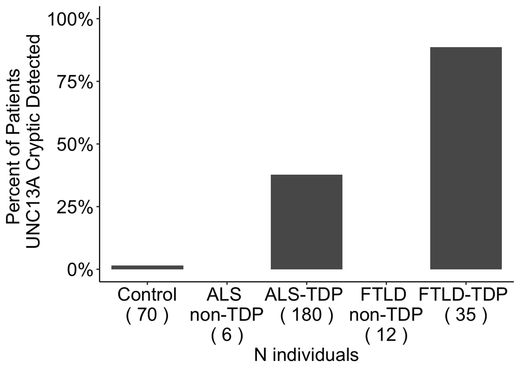

```r
boxplot_table %>%
  filter(disease_tissue == T) %>%
  mutate(detected = inclusion_reads > 0) %>%
  dplyr::select(participant_id,disease_group2,detected) %>%
  unique() %>%
  group_by(disease_group2) %>%
  mutate(n_sample = n_distinct(participant_id)) %>%
  mutate(n_sample_detected = sum(detected)) %>%
  dplyr::select(disease_group2,n_sample,n_sample_detected) %>%
  unique() %>%
  mutate(detection_rate = n_sample_detected / n_sample) %>%
  mutate(disease_group2 = gsub("Control"," Control",disease_group2)) %>%
  mutate(detection_name = glue::glue("{disease_group2} \n ( {n_sample} )")) %>%
  ggplot() +
  geom_col(aes(x = detection_name, y = detection_rate)) +
  ggpubr::theme_pubr() +
  scale_y_continuous(lim = c(0,1),labels = scales::percent) +
  ylab("Percent of Patients \n UNC13A Cryptic Detected") +
  theme(text = element_text(size = 18)) +
  xlab("N individuals")
```

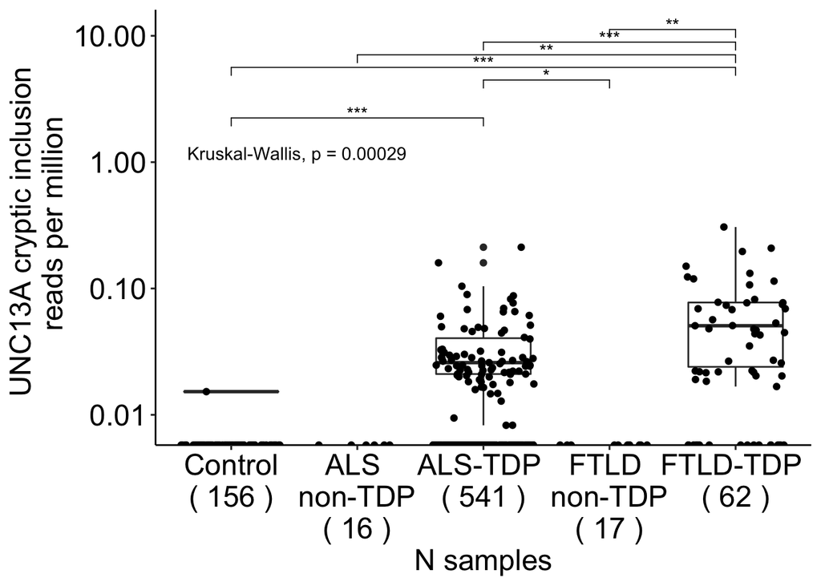

```r
disease_comparisons = list( c("Control","ALS-TDP"),
                           c("Control","ALS \n non-TDP"),
                           c("Control","FTLD-TDP"),
                           c("Control","FTLD \n non-TDP" ))

table_to_test = boxplot_table %>%
    filter(disease_tissue == T) %>%
    group_by(disease_group2) %>%
    mutate(n_sample = n_distinct(sample)) %>%
    mutate(disease_group2 = gsub("Control"," Control",disease_group2)) %>%
    mutate(detection_name = glue::glue("{disease_group2} \n ( {n_sample} )")) %>%
    dplyr::select(detection_name,
                  participant_id,
                  inclusion_reads,
                  disease_group2) %>%
    unique()

test_pair = pairwise.wilcox.test(table_to_test$inclusion_reads, table_to_test$detection_name,
                     p.adjust.method = "BH") %>% broom::tidy()

test_pair = test_pair %>%
  mutate(p_value_draw = case_when(p.value < 0.0001~ "***",
                                  p.value < 0.01 ~ "**",
                                   p.value < 0.05 ~ "*",
                          TRUE ~ paste0("Adj. p-value \n",as.character(round(p.value,2))))) %>%
  mutate(y.position = seq(0.25,by = 0.1,length.out = 9))

table_to_test %>%
    ggplot(aes(x = detection_name, y = inclusion_reads * 10^6)) +
    geom_boxplot() +
    geom_jitter(height = 0) +
    scale_y_log10() +
    ggpubr::theme_pubr() +
    ylab("UNC13A cryptic inclusion \n reads per million") +
    theme(text = element_text(size = 18)) +
    xlab("N samples") +
    stat_pvalue_manual(test_pair %>% filter(p.value < 0.05),
                       label = "p_value_draw") +
   stat_compare_means()
```

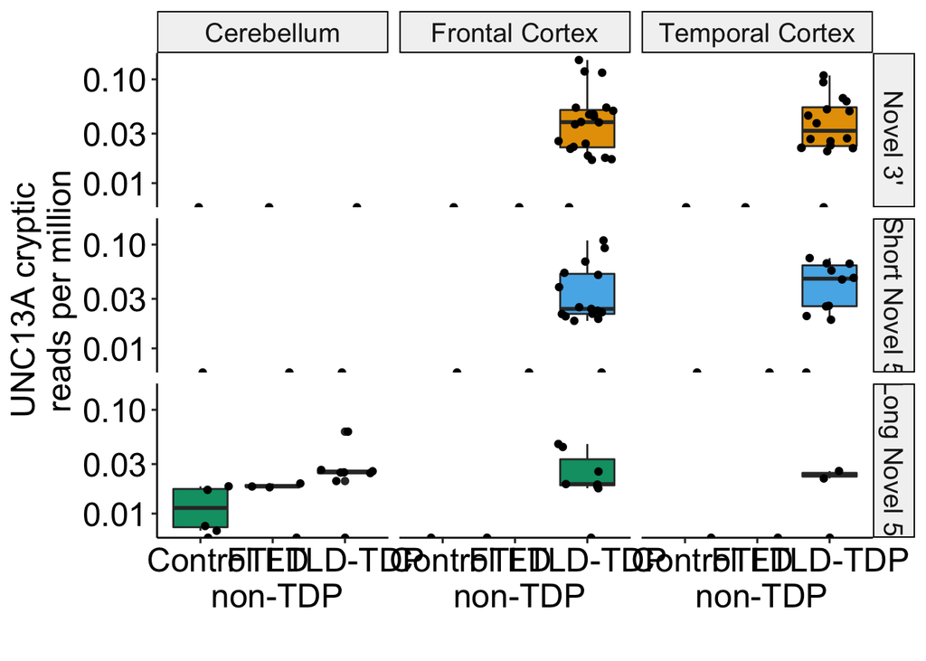

```r
####Inclusion reads by if TDP-potential####
boxplot_table %>%
  filter(disease_group2 %in% c("Control",
                              "FTLD \n non-TDP",
                              "FTLD-TDP")) %>%
    filter(tissue_clean %in% c("Cerebellum","Frontal Cortex","Temporal Cortex")) %>%
  dplyr::select(disease_group2,
                tissue_clean,
                junction_name,
                value) %>%
  unique() %>%
    ggplot(aes(x = disease_group2,
               y = value * 10^6,
               fill = junction_name)) +
    geom_boxplot(show.legend = F) +
    geom_jitter(height = 0,show.legend = F) +
    scale_y_log10() +
    ggpubr::theme_pubr() +
    facet_grid(vars(junction_name),vars(tissue_clean)) +
    ylab("UNC13A cryptic \n reads per million") +
    theme(text = element_text(size = 18)) +
    xlab("") +
    scale_fill_manual(values = colorblind_pal()(4)[2:4])
```

Splitting by the type of junction in ALS

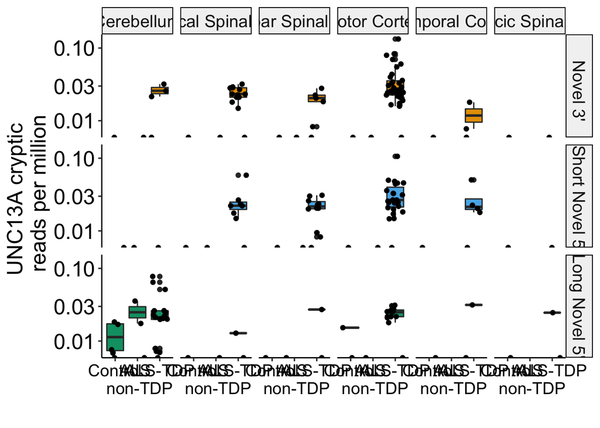

```r
####Inclusion reads by if TDP-potential####
boxplot_table %>%
  filter(disease_group2 %in% c("Control",
                              "ALS \n non-TDP",
                              "ALS-TDP")) %>%
      filter(tissue_clean %in% c("Cerebellum","Motor Cortex","Temporal Cortex") | grepl("Cord",tissue_clean)) %>%
  dplyr::select(disease_group2,
                tissue_clean,
                junction_name,
                value) %>%
  unique() %>%
  mutate(disease_group2 = fct_relevel(disease_group2,"Control","ALS \n non-TDP","ALS-TDP")) %>%
    ggplot(aes(x = disease_group2,
               y = value * 10^6,
               fill = junction_name)) +
    geom_boxplot(show.legend = F) +
    geom_jitter(height = 0,show.legend = F) +
    scale_y_log10() +
    ggpubr::theme_pubr() +
    facet_grid(vars(junction_name),vars(tissue_clean)) +
    ylab("UNC13A cryptic \n reads per million") +
    theme(text = element_text(size = 18)) +
    xlab("") +
    scale_fill_manual(values = colorblind_pal()(4)[2:4]) +
  theme(axis.text.x =  element_text(size = 14))
```

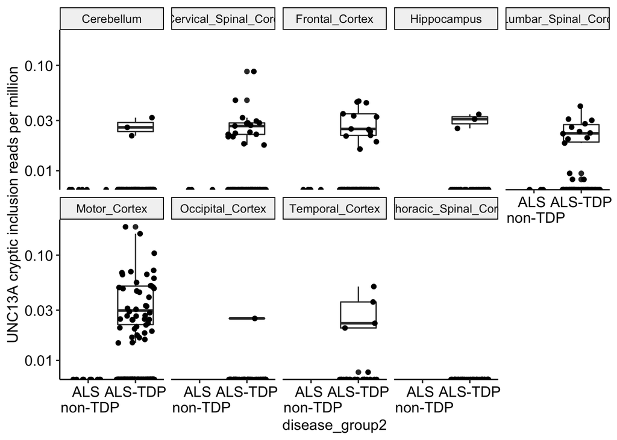

```r
clean_data_table %>%
    mutate(disease_group2 = case_when(disease == "Control" ~ "Control",
                                 pathology %in% c("FTD-TDP-A","FTD-TDP-B","FTD-TDP-C") ~ "FTLD-TDP",
                                 pathology %in% c("FTLD-TAU","FTLD-FUS") ~ "FTLD-non-TDP",
                                 mutations %in% c("SOD1","FUS") ~ "ALS \n non-TDP",
                                 T ~ "ALS-TDP")) %>%
    filter(disease_group2 %in% c("ALS \n non-TDP","ALS-TDP")) %>%
    mutate(across(UNC13A_3prime_leaf:UNC13A_annotated_leaf, ~ .x / library_size,.names = "{.col}_library_norm")) %>%
    filter(!tissue_clean %in% c("Choroid","Liver")) %>%
    dplyr::select(sample,disease_group2,tissue_clean,contains("_library_norm")) %>%
    melt() %>%
    filter(grepl("_3prime|_5prime_1",variable)) %>%
    group_by(sample) %>%
    mutate(inclusion_reads = sum(value)) %>%
    ungroup() %>%
    dplyr::select(-variable,-value) %>%
    unique() %>%
    ggplot(aes(x = disease_group2, y = inclusion_reads * 10^6)) +
    geom_boxplot() +
    geom_jitter(height = 0) +
    facet_wrap(~tissue_clean,nrow = 2) +
    scale_y_continuous(trans = 'log10') +
    ggpubr::theme_pubr() +
    ylab("UNC13A cryptic inclusion reads per million")
```

# Relationship between UNC13A and STMN2 cryptic PSI

We noted in the cell lines that there was a linear relationship between the amount of TARDBP KD efficiency and the amount of observed UNC13A cryptic. As a quantitative measure of TDP-43 proteinopathy does not exist for these patients, no ranked staining, we used the amount of STMN2 present in a tissue to rank the tissue by the amount of TDP-43 proteinopathy, as we’ve already shown you can use that as a measure. Here we show the relationship in samples with at least 10 STMN2 annotated junctions and tissues where the PSI of UNC13A cryptic was also detectable, as measured by STMN2 cryptic occurring in the tissue.

## Scatter plot showing the relationship in non-logspace between STMN2 and UNC13A cryptic PSI

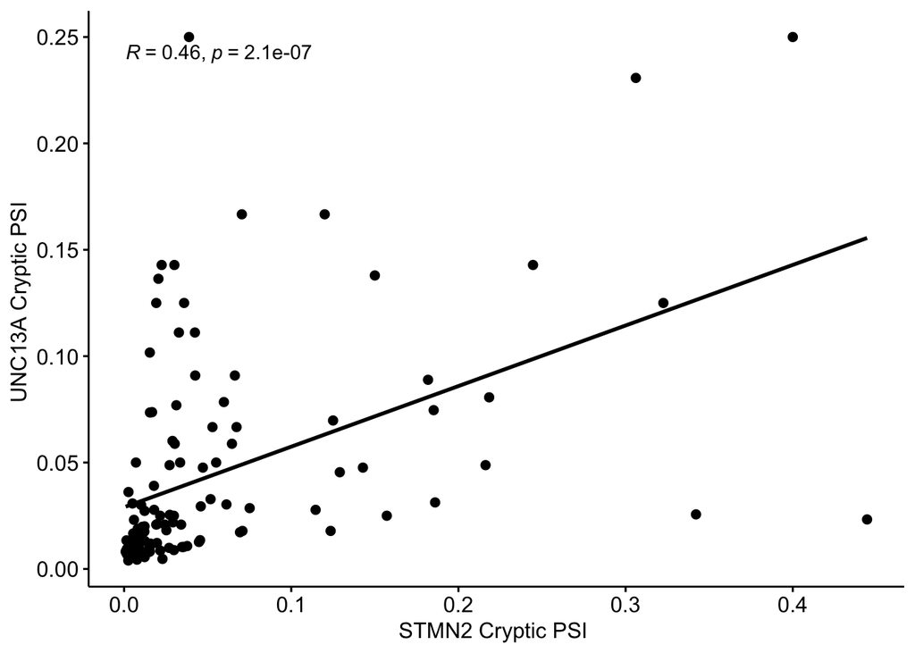

```r
####scatter plot showing the correlation in non-log space in STMN2 and cryptic PSI####
clean_data_table %>%
    filter(STMN2_annotated_leaf > 10) %>%
    filter(stmn_2_cryptic_psi_leaf > 0 ) %>%
    filter(unc13a_cryptic_leaf_psi > 0 ) %>%
    group_by(call) %>%
    ggpubr::ggscatter(.,
                      x = "stmn_2_cryptic_psi_leaf",
                      y = "unc13a_cryptic_leaf_psi",
                      add = "reg.line",
                      cor.coef = T) +
    ylab("UNC13A Cryptic PSI ") +
    xlab("STMN2 Cryptic PSI ")
```

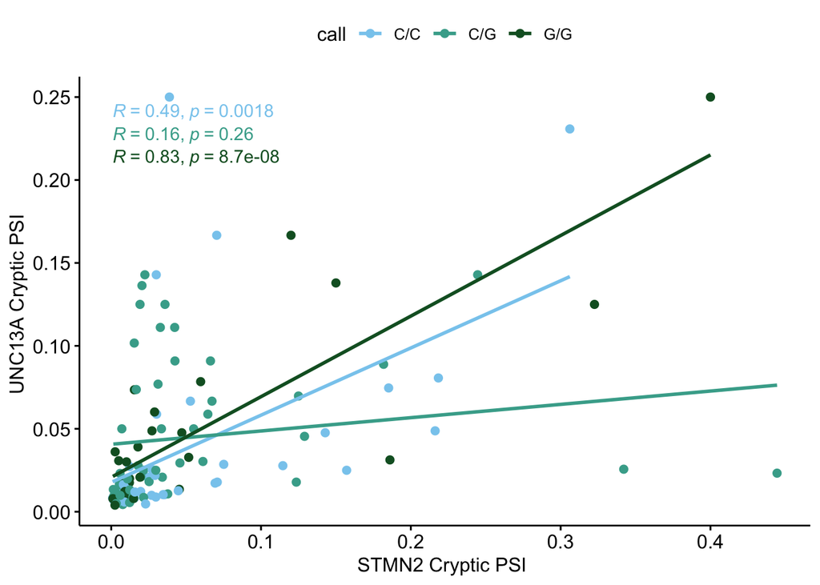

```r
####scatter plot showing the correlation in non-log space in STMN2 and cryptic PSI####
clean_data_table %>%
    filter(STMN2_annotated_leaf > 10) %>%
    filter(stmn_2_cryptic_psi_leaf > 0 ) %>%
    filter(unc13a_cryptic_leaf_psi > 0 ) %>%
    mutate(call = fct_relevel(call,"C/C", "C/G", "G/G")) %>%
    group_by(call) %>%
    ggpubr::ggscatter(.,
                      x = "stmn_2_cryptic_psi_leaf",
                      y = "unc13a_cryptic_leaf_psi",
                      add = "reg.line",
                      color = "call") +
    ylab("UNC13A Cryptic PSI ") +
    xlab("STMN2 Cryptic PSI ") +
    stat_cor(aes(color = call),show.legend = FALSE) +
    scale_color_manual(values = c("#88CCEE","#44AA99","#105e2a"))
```

You can see a clear relationship, which appears to be modulated by the genotype of rs12973192. This lead us to see if genotype was actually predictive of the amount of UNC13A cryptic psi. Because PSI’s tend to be log linear, we chose to model UNC13A in the log10 + 1 (log10(1) is zero) and we selected for tissues which show TDP-43 pathology, as we assume this is an event which only begins to show clear after TDP-43 pathology arises.

## Scatter plot showing the relationship in log + 1 between STMN2 and UNC13A cryptic PSI

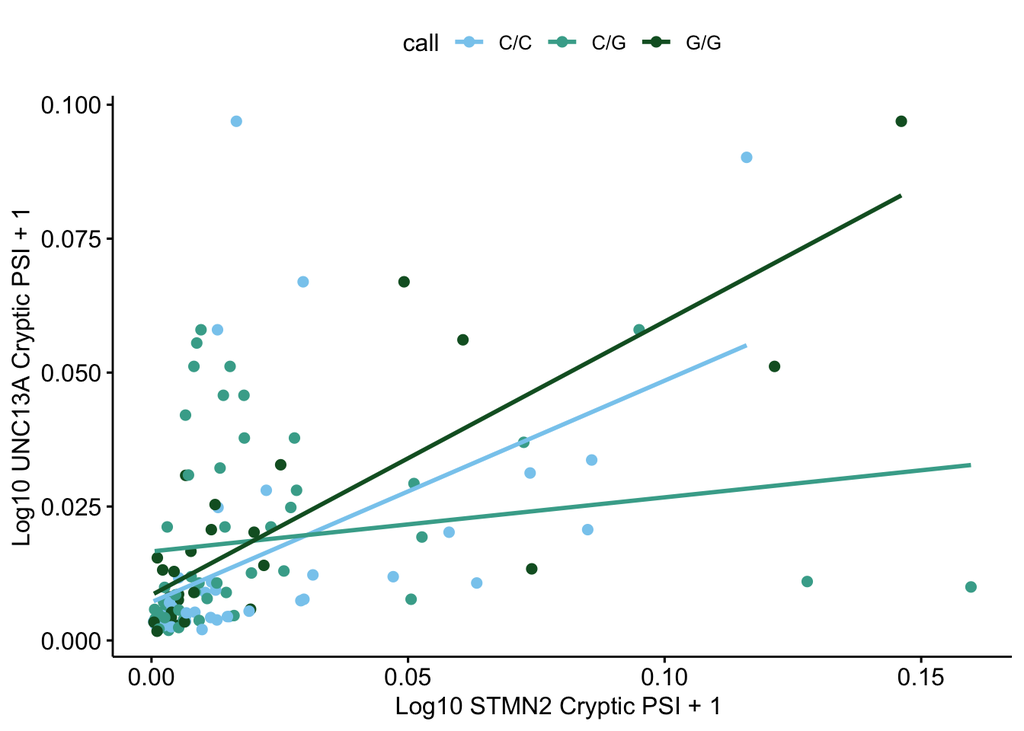

```r
clean_data_table %>%
    mutate(call = fct_relevel(call,
                              "C/C", "C/G", "G/G")) %>%
    filter(STMN2_annotated_leaf > 10) %>%
    filter(stmn_2_cryptic_psi_leaf > 0 ) %>%
    filter(unc13a_cryptic_leaf_psi > 0 ) %>%
    mutate(log10_stmn_2_cryptic_psi_leaf_plusone = log10(stmn_2_cryptic_psi_leaf + 1)) %>%
    mutate(log10_unc13a_cryptic_leaf_psi_plusone = log10(unc13a_cryptic_leaf_psi + 1)) %>%
    group_by(call) %>%
    ggpubr::ggscatter(.,
                      x = "log10_stmn_2_cryptic_psi_leaf_plusone",
                      y = "log10_unc13a_cryptic_leaf_psi_plusone",
                      color = 'call',fill = 'call',
                      add = "reg.line") +
    ylab("Log10 UNC13A Cryptic PSI + 1") +
    xlab("Log10 STMN2 Cryptic PSI + 1 ") +
    scale_color_manual(values = c("#88CCEE","#44AA99","#105e2a")) +
    scale_fill_manual(values = c("#88CCEE","#44AA99","#105e2a"))
```

We can perform this analysis separated by tissue, but low numbers make the results more complicated to interpret. Additionally, the tissue only matters in so much as we know that certain tissues in certain diseases are affected by TDP-43 pathology, whereas others aren’t, tissue is not the most interesting or important variable, TDP-43 pathology is the question.

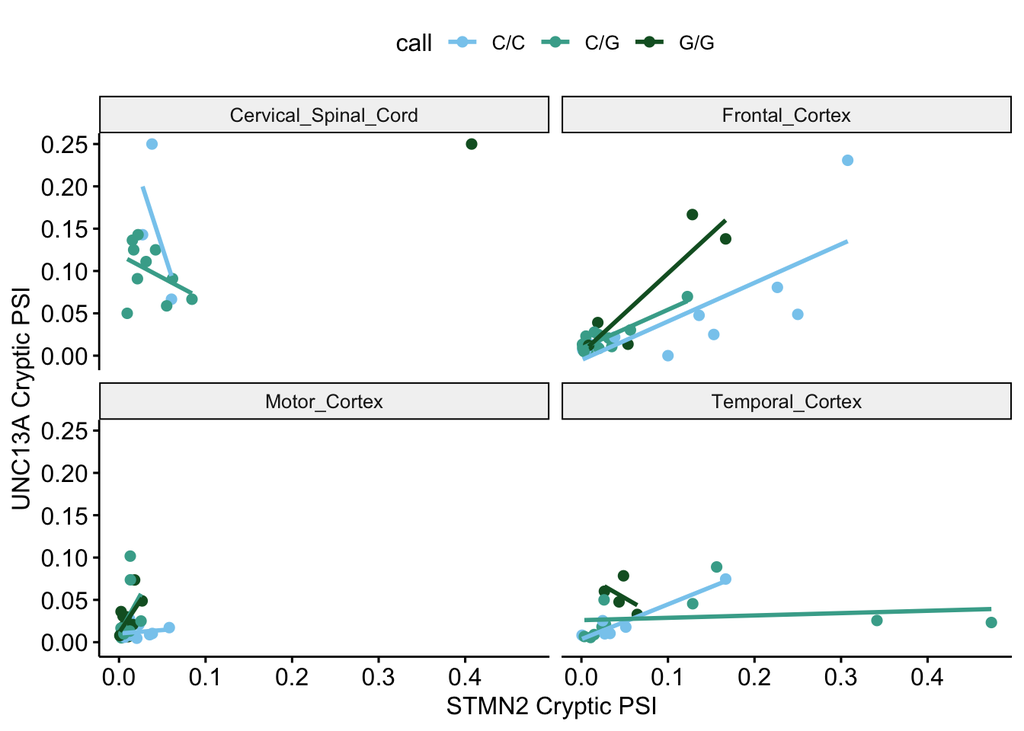

```r
####scatter plot showing the correlation in non-log space in STMN2 and cryptic PSI####
clean_data_table %>%
    filter(tissue_clean%in% c("Cervical_Spinal_Cord",
                              "Motor_Cortex",
                              "Frontal_Cortex","Temporal_Cortex")) %>%
    mutate(call = fct_relevel(call,
                              "C/C", "C/G", "G/G")) %>%
    filter(STMN2_annotated_leaf > 10) %>%
    filter(cryptic_psi > 0 ) %>%
    filter(stmn_2_cryptic_psi > 0 ) %>%
    group_by(call) %>%
    ggpubr::ggscatter(.,
                      x = "stmn_2_cryptic_psi",
                      y = "unc13a_cryptic_leaf_psi",
                      color = 'call',
                      add = "reg.line") +
    ylab("UNC13A Cryptic PSI ") +
    xlab("STMN2 Cryptic PSI ") +
    scale_color_manual(values = c("#88CCEE","#44AA99","#105e2a")) +
    facet_wrap(~tissue_clean)
```

## Modeling UNC13A cryptic using glms and mixed models

This brought us to the idea that we could even potentially model UNC13A cryptic pathology using genotype and the amount of TDP-43 pathology. We’ve coded the number of G alleles here as a number and are looking into tissue with TDP-43 pathology(measure with STMN2 cryptic PSI).

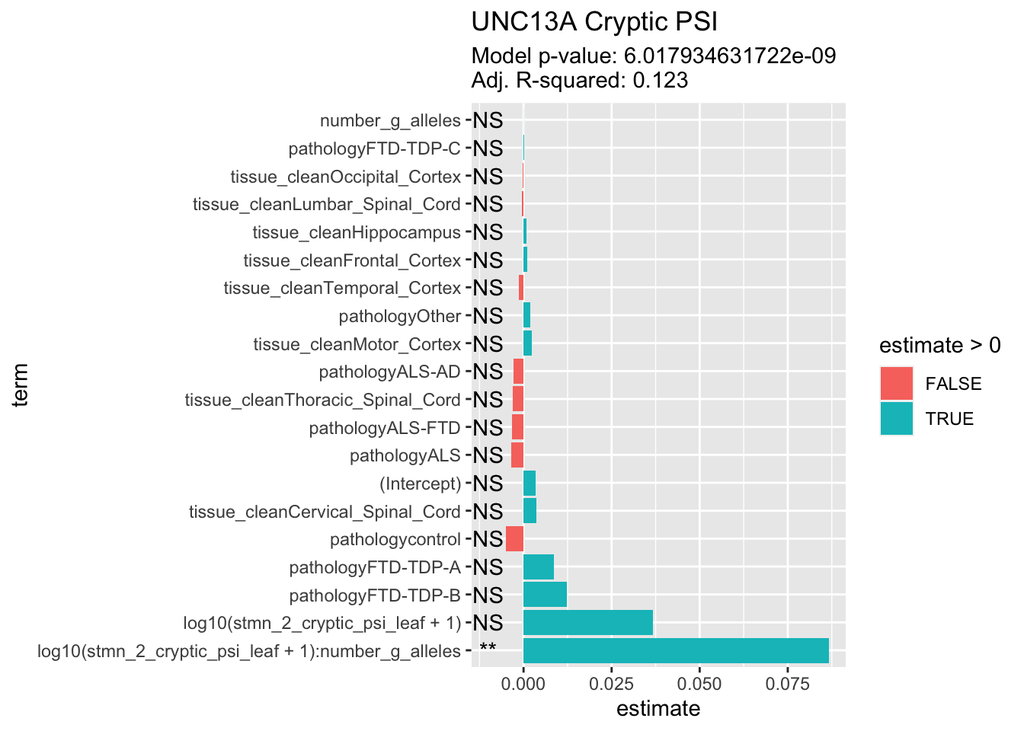

```r
new_regress = clean_data_table %>%
    mutate(call = fct_relevel(call,
                              "C/C", "C/G", "G/G")) %>%
    filter(STMN2_annotated_leaf > 10) %>%
    filter(stmn_2_cryptic_psi_leaf > 0 ) %>%
    mutate(log10_stmn_2_cryptic_psi_leaf = log10(stmn_2_cryptic_psi_leaf)) %>%
    mutate(log10_unc13a_cryptic_leaf_psi_plusone = log10(unc13a_cryptic_leaf_psi + 1)) %>%
    mutate(log10_stmn_2_cryptic_psi_leaf_plusone = log10(stmn_2_cryptic_psi_leaf + 1))


another_model2 = lm(log10(unc13a_cryptic_leaf_psi + 1) ~
                   log10(stmn_2_cryptic_psi_leaf + 1) * number_g_alleles + pathology + tissue_clean,
              new_regress)

print(pretty_effect_plot(another_model2,p_value_cutoff = 1,"UNC13A Cryptic PSI"))
```

We find that at a cutoff of 0.01 for significant effects, only the interaction between the number of G alleles and the amount of STMN2 pathology is predictive of UNC13A cryptic inclusion. the absolute amount of STMN2 pathology does not vary between genotypes.

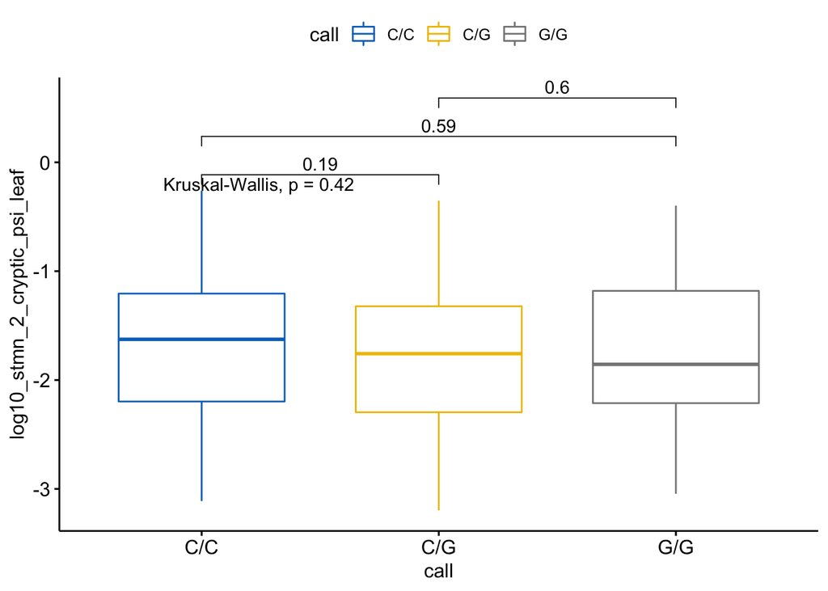

```r
genotype_comparisons = list(c("C/C", "C/G"), c("C/C", "G/G"), c("C/G", "G/G"))


ggboxplot(new_regress, x = "call", y = "log10_stmn_2_cryptic_psi_leaf",
          color = "call", palette = "jco")+
  stat_compare_means() +
  stat_compare_means(comparisons = genotype_comparisons)
```

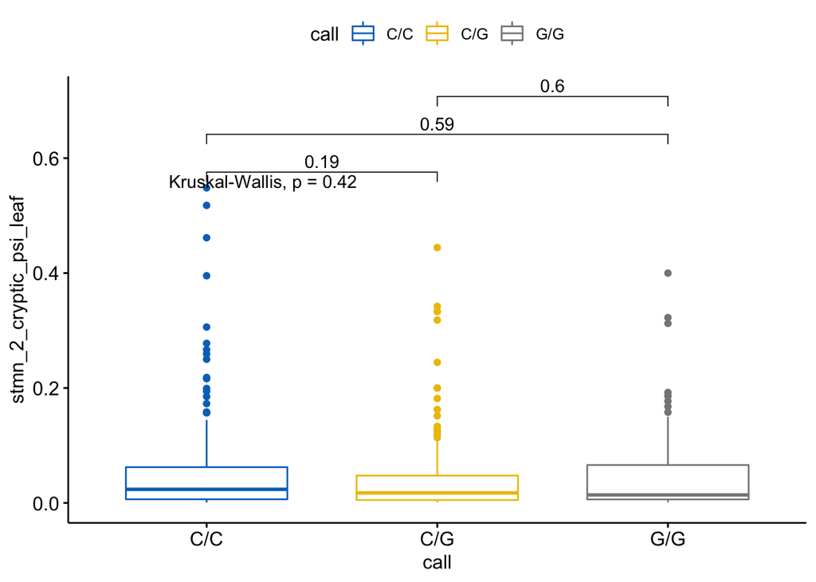

```r
ggboxplot(new_regress, x = "call", y = "stmn_2_cryptic_psi_leaf",
          color = "call", palette = "jco")+
  stat_compare_means() +
  stat_compare_means(comparisons = genotype_comparisons)
```

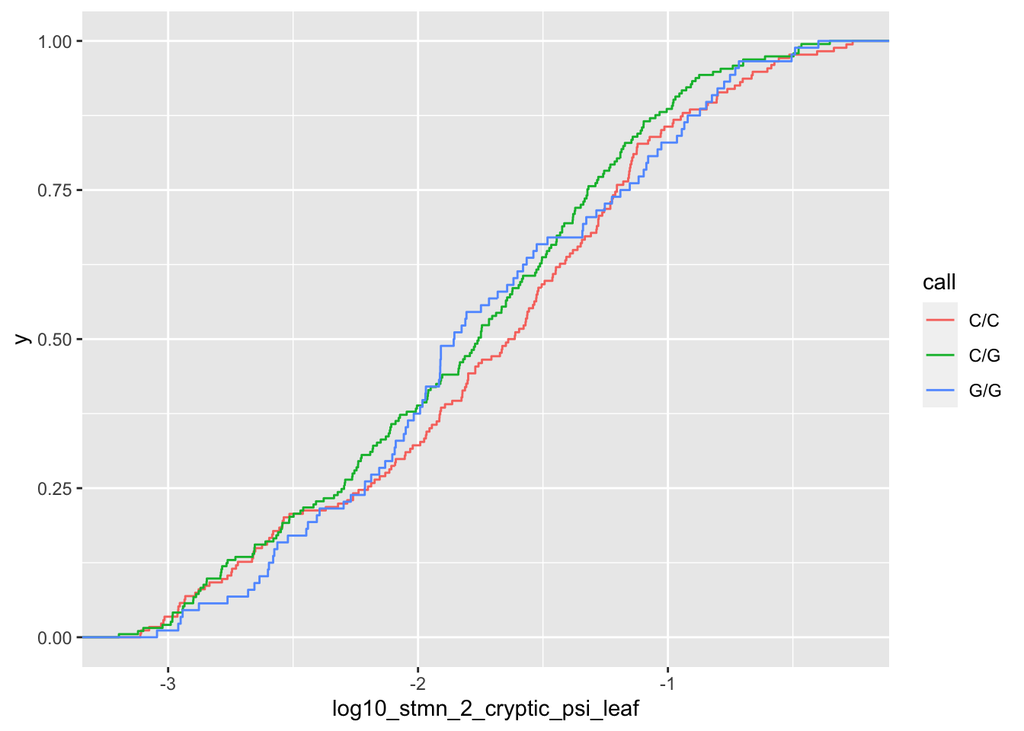

```r
new_regress %>%
    ggplot() +
    stat_ecdf(aes(color = call, x = log10_stmn_2_cryptic_psi_leaf))
```

We see that detection rate by genotype varies.

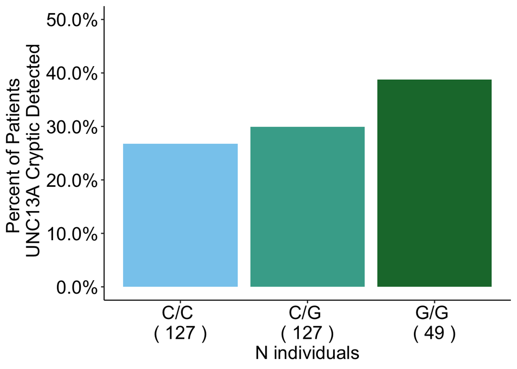

```r
overall_fisher = clean_data_table %>%
  left_join(boxplot_table %>% select(sample,
                                     disease_tissue,
                                     disease_group2)) %>%
  unique() %>%
  filter(disease_tissue == T) %>%
  mutate(unc13a_detected = unc13a_cryptic_leaf_psi > 0) %>%
  dplyr::select(participant_id,disease_group2,unc13a_detected,call) %>%
  unique() %>%
  group_by(call) %>%
  mutate(n_sample = n_distinct(participant_id)) %>%
  mutate(n_sample_detected = sum(unc13a_detected)) %>%
  dplyr::select(call,n_sample,n_sample_detected) %>%
  unique()
over_p = overall_fisher %>%
  column_to_rownames('call') %>%
  fisher.test() %>%
  broom::tidy() %>%
  .$p.value

overall_fisher %>%
  mutate(detection_rate = n_sample_detected / n_sample) %>%
  mutate(detection_name = glue::glue("{call} \n ( {n_sample} )")) %>%
  ggplot(aes(x = detection_name, y = detection_rate, fill = detection_name)) +
  geom_col(show.legend = F) +
  ggpubr::theme_pubr() +
  scale_y_continuous(lim = c(0,0.5),labels = scales::percent) +
  ylab("Percent of Patients \n UNC13A Cryptic Detected") +
  theme(text = element_text(size = 18)) +
  xlab("N individuals") +
  scale_fill_manual(values = c("#88CCEE","#44AA99","#1B7739"))
```

Although this difference is not signficant, with the Fisher’s exact giving a p-value of 0.5321053. But the effect is masked We see that detection rate by genotype varies

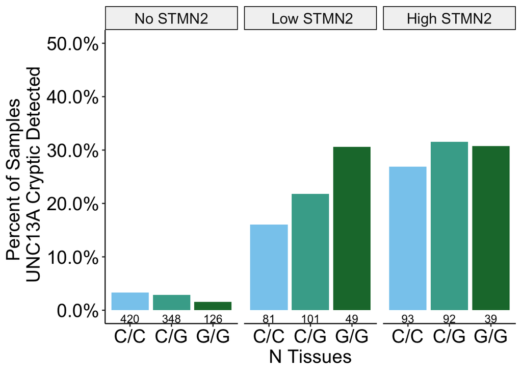

```r
detection_table = clean_data_table %>%
  mutate(unc13a_detected = unc13a_cryptic_leaf_psi > 0) %>%
  group_by(call,unc13a_detected,stmn2_psi_groups) %>%
  add_count(name = "genotype_detected") %>%
  dplyr::select(call,unc13a_detected,genotype_detected,stmn2_psi_groups) %>%
  unique() %>%
  pivot_wider(names_from = "unc13a_detected",
              values_from = "genotype_detected") %>%
  dplyr::rename(unc_not_detected = `FALSE`, unc_cryptic_detected = `TRUE`) %>%
  mutate(total_tissue = (unc_not_detected + unc_cryptic_detected)) %>%
  mutate(detection_rate = unc_cryptic_detected / total_tissue) %>%
  ungroup() %>%
  mutate(stmn2_psi_groups = fct_relevel(stmn2_psi_groups, "No STMN2", after = 0))

detection_table %>%
  ggplot(aes(x = call, y = detection_rate,fill = call)) +
  geom_col(show.legend = F) +
  facet_wrap(~stmn2_psi_groups) +
  geom_text(aes(label = total_tissue, y = 0),vjust = 1.5) +
  ggpubr::theme_pubr() +
  scale_fill_manual(values = c("#88CCEE","#44AA99","#1B7739")) +
  scale_y_continuous(lim = c(0,0.5),labels = scales::percent) +
  ylab("Percent of Samples \n UNC13A Cryptic Detected") +
  theme(text = element_text(size = 18)) +
  xlab("N Tissues")
```